# DIF plots again: A correction

Ivailo Partchev

2025-02-10

Source: [`vignettes/blog/2025-02-10-correction-dif-plots.Rmd`](https://github.com/dexter-psychometrics/dexter/blob/master/vignettes/blog/2025-02-10-correction-dif-plots.Rmd)

A post or two ago I proposed a clustered heatmap as an optimal graphical representation of the item pair DIF statistics in **dexter**. While the plots are helpful and easy to read, they are still not exactly what I wanted. The code within the **pheatmap** package first computes a distance matrix of the inputs and then performs cluster analysis, while I argue that the differences (called *Delta_R* in the dexter object and *distances* here) are distances in themselves. Working with the distances between the distances is a bit far-fetched so, to get what I originally wanted, we simply replace `dist(dist)` with `as.dist(dist)`. With that change and some adjustment to the plot when `what="distances"`, the code now becomes:

```r
DIFplot = function(d,
  what=c('distances','statistics','pvalues','significance'),
  pam=c("none", "holm", "hochberg", "hommel", "bonferroni", "BH", "BY",
     "fdr"), cluster = TRUE, alpha=0.05, ...) {
  what = match.arg(what)
  pam = match.arg(pam)
  alpha = alpha/2
  dist = abs(d$Delta_R)
  o = hclust(as.dist(dist))$order
  lbl = d$items$item_id
  stat = abs(d$DIF_pair)
  outl = lbl[o]
  if (cluster) {stat=stat[o,o]; lbl=lbl[o]}
  pval = 1 - pnorm(stat)
  u0 = pval[lower.tri(pval)]
  u1 = p.adjust(u0, method=pam)
  pval[lower.tri(pval)] = u1

  if(what=='distances') {
    if (cluster) { dist = dist[o,o] }
    rownames(dist) = colnames(dist) = lbl
    diag(dist) = NA
    pheatmap::pheatmap(dist, main='PDIF: raw differences', cluster_rows=FALSE, cluster_cols=FALSE)
  }
  if(what=='statistics') {
    rownames(stat) = colnames(stat) = lbl
    diag(stat) = NA
    pheatmap::pheatmap(stat, main='PDIF: standardized differences', cluster_rows=FALSE, cluster_cols=FALSE)
  }
  if(what=='pvalues') {
    rownames(pval) = colnames(pval) = lbl
    diag(pval) = NA
    ttl = 'PDIF: p-values'
    if (pam != 'none') ttl=paste0(ttl, ' (below diagonal adjusted by ',pam,')')
    pheatmap::pheatmap(pval,
      main = ttl,
      cluster_rows=FALSE, cluster_cols=FALSE,
      color = colorRampPalette(RColorBrewer::brewer.pal(n=7, name="RdYlBu"))(100))
  }
  if(what=='significance') {
    ttl = paste0('PDIF: significance at alpha=',2*alpha)
    if (pam != 'none') ttl=paste0(ttl, ' (b/d adjusted by ',pam,')')
    v = (0 + (pval<alpha))
    rownames(v) = colnames(v) = lbl
    diag(v) = NA
    pheatmap::pheatmap(v, main=ttl, cluster_rows=FALSE, cluster_cols=FALSE, legend=FALSE)
  }
  return(outl)
}
```

Looking at the new clustered plot of the differences (aka distances), we see that it is rearranged but does not show the dendrograms, in line with the other plots. However, it has barely changed otherwise for this particular example. Still, I wanted to have it my way because the change might matter in other examples.

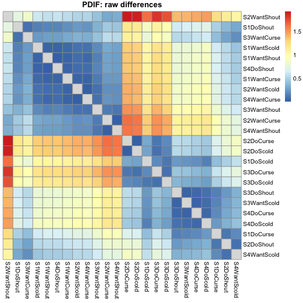

```r
pl = DIFplot(d, what='distances', cluster=TRUE)
```